# Lab 6 - Inference for Numerical Data

202330420212 - Sihan Chen & 202364820921 - Yue Zhang

2025-05-14

# 1 Introduction

In this lab, we explore statistical inference using numerical data from a real-world dataset on births in North Carolina. We investigate relationships between variables such as birth weight, maternal smoking, gestation length, and weight gain using confidence intervals and hypothesis testing.

**Objectives of this lab include:**

- Understand the sampling distribution of the mean
- Construct confidence intervals from sample statistics
- Interpret the meaning of confidence intervals
- Conduct hypothesis tests to compare population groups
- Visualize relationships between numerical and categorical variables

# 2 Exploratory analysis

This section introduces the structure and contents of the North Carolina births dataset. We identify what the cases represent and explore the variable types and sample size. Initial data visualizations allow us to understand distributions and potential group-level differences before conducting formal inference.

## 2.1 Exercise 1 - Cases and Sample Size

Understanding the size and scope of a dataset is essential before drawing inferences. Here we identify the observational unit and total sample size.

**Question:** What are the cases in this data set? How many cases are there in our sample?

**Answer:** *The cases are individual birth records in North Carolina. The sample size is 1000.*

## 2.2 Exercise 2 - Side-by-Side Boxplot of Weight by Smoking Habit

We use visual exploration to detect potential associations between maternal smoking habits and infant birth weights.

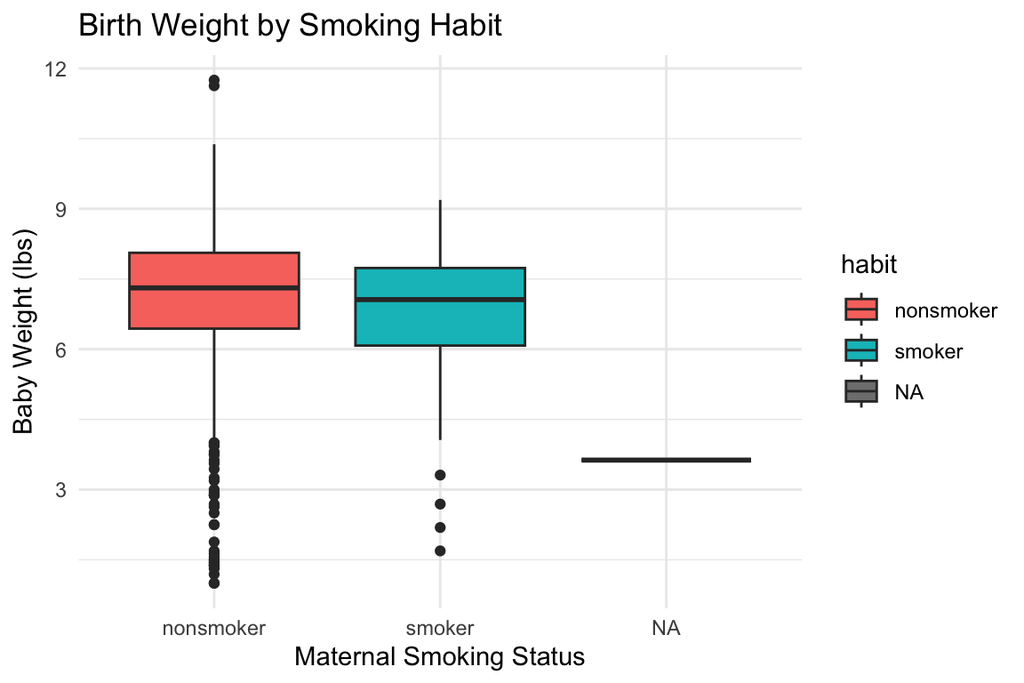

```r
ggplot(nc, aes(x = habit, y = weight, fill = habit)) +
  geom_boxplot() +
  labs(title = "Birth Weight by Smoking Habit", x = "Maternal Smoking Status", y = "Baby Weight (lbs)") +
  theme_minimal()
```

# 3 Inference

We now transition from exploratory analysis to statistical inference. We begin by setting formal hypotheses and then estimate population differences using confidence intervals and hypothesis testing.

## 3.1 Exercise 3 - Hypotheses for Weight by Habit

**Null Hypothesis (H0):** The average weights of babies born to smokers and non-smokers are equal.  
**Alternative Hypothesis (HA):** The average weights of babies born to smokers and non-smokers are different.

## 3.2 Exercise 4 - Confidence Interval for Difference in Means

```r
newinf(y = nc$weight, x = nc$habit, est = "mean", type = "ci", null = 0,
       alternative = "twosided", method = "theoretical", order = c("smoker", "nonsmoker"))
```

```
## Response variable: numerical, Explanatory variable: categorical
## Difference between two means
## Summary statistics:
## n_smoker = 126, mean_smoker = 6.8287, sd_smoker = 1.3862
## n_nonsmoker = 873, mean_nonsmoker = 7.1443, sd_nonsmoker = 1.5187
```

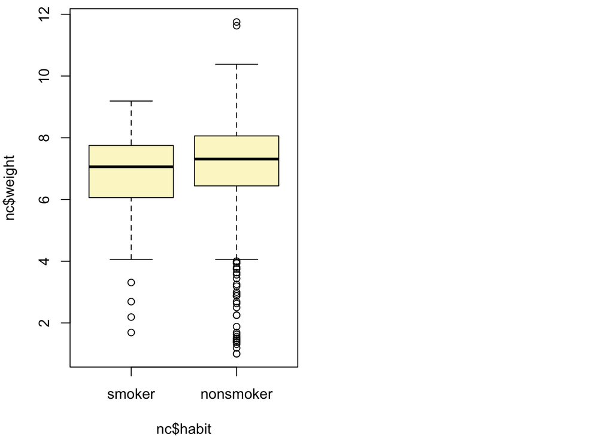

```
## Observed difference between means (smoker-nonsmoker) = -0.3155
## Standard error = 0.1338
## 95 % Confidence interval = ( -0.5777 , -0.0534 )
```

**Interpretation:** This confidence interval estimates the difference in average baby weight between smoking and non-smoking mothers. If the interval does not contain 0, the difference is statistically significant.

# 4 Additional Exercises

In the following exercises, we apply inference to other numerical variables, vary confidence levels, and test for group differences in different contexts.

## 4.1 Exercise 5 - CI for Average Pregnancy Length

```r
newinf(y = nc$weeks, est = "mean", type = "ci", method = "theoretical")
```

```
## Single mean
## Summary statistics:
```

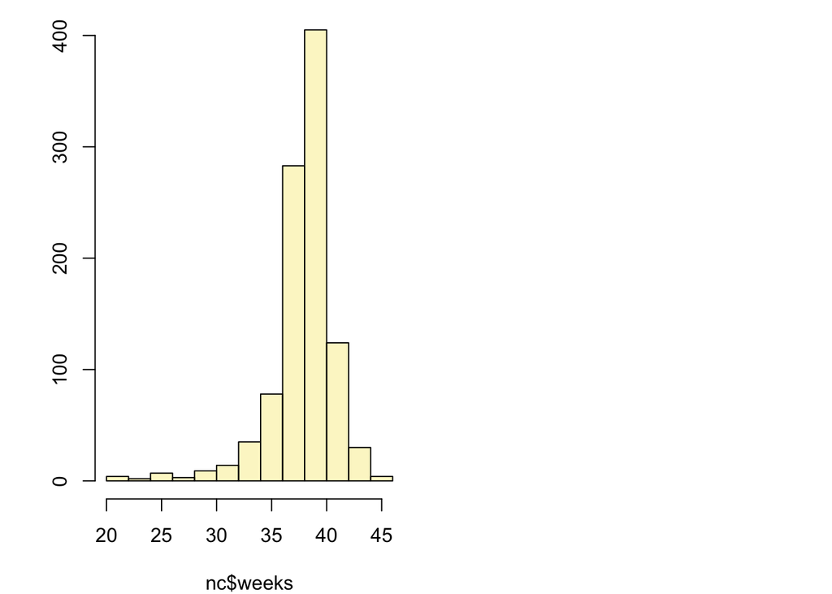

```
## mean = 38.3347 ;  sd = 2.9316 ;  n = 998
## Standard error = 0.0928
## 95 % Confidence interval = ( 38.1528 , 38.5165 )
```

**Interpretation:** This confidence interval estimates the population mean gestation length. A narrower CI indicates higher precision.

## 4.2 Exercise 6 - 90% CI for Pregnancy Length

```r
newinf(y = nc$weeks, est = "mean", type = "ci", method = "theoretical", conflevel = 0.90)
```

```
## Single mean
## Summary statistics:
```

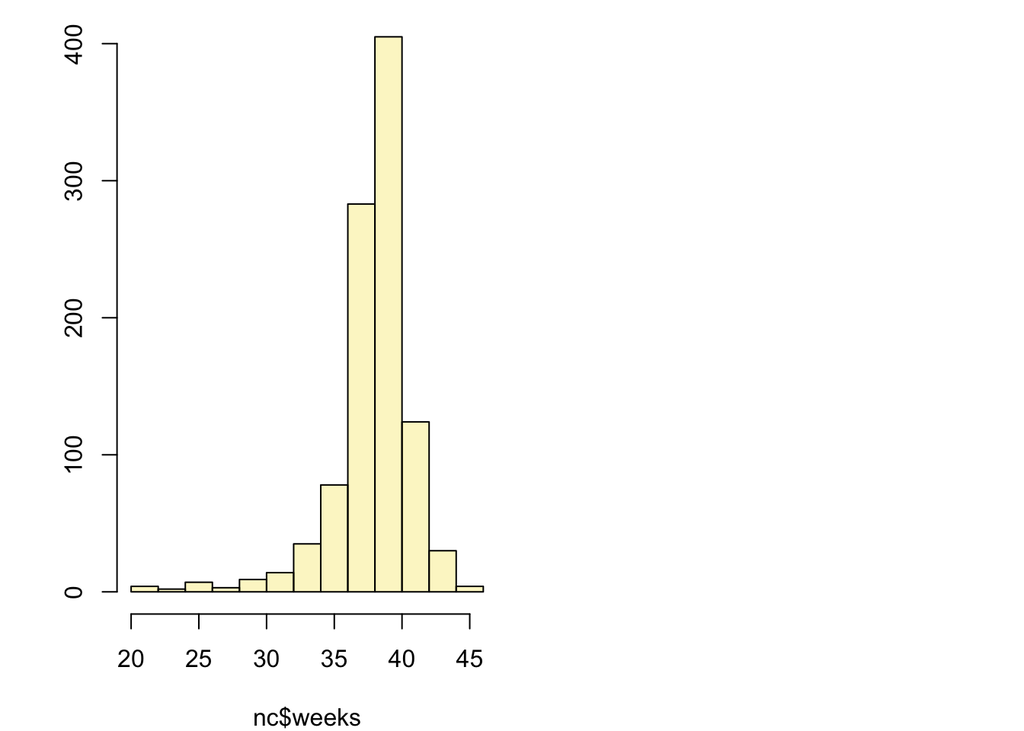

```
## mean = 38.3347 ;  sd = 2.9316 ;  n = 998
## Standard error = 0.0928
## 90 % Confidence interval = ( 38.182 , 38.4873 )
```

**Interpretation:** A 90% CI is narrower than a 95% CI but comes with lower confidence. This highlights the trade-off between certainty and precision.

## 4.3 Exercise 7 - Hypothesis Test on Weight Gain by Maternal Maturity

```r
newinf(y = nc$gained, x = nc$mature, est = "mean", type = "ht", null = 0,
       alternative = "twosided", method = "theoretical",
       order = c("younger mom", "mature mom"))
```

```
## Response variable: numerical, Explanatory variable: categorical
## Difference between two means
## Summary statistics:
## n_younger mom = 844, mean_younger mom = 30.5604, sd_younger mom = 14.3469
## n_mature mom = 129, mean_mature mom = 28.7907, sd_mature mom = 13.4824
```

```
## Observed difference between means (younger mom-mature mom) = 1.7697
## H0: mu_younger mom - mu_mature mom = 0
## HA: mu_younger mom - mu_mature mom != 0
## Standard error = 1.286
## Test statistic: Z =  1.376
## p-value =  0.1686
```

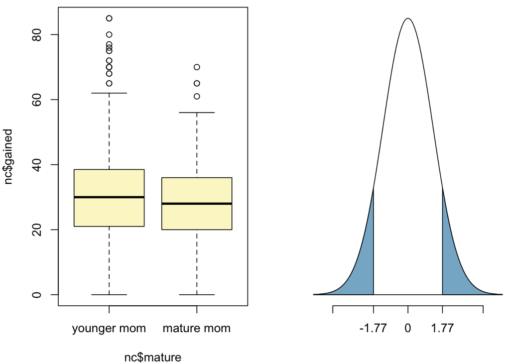

**Interpretation:** This test assesses whether mature and younger mothers differ in weight gain during pregnancy. A significant result implies that maternal age group is associated with weight gain.

## 4.4 Exercise 8 - Age Cutoff Between Younger and Mature Mothers

Visualizing the distribution of maternal age can help identify how the “mature” classification is defined.

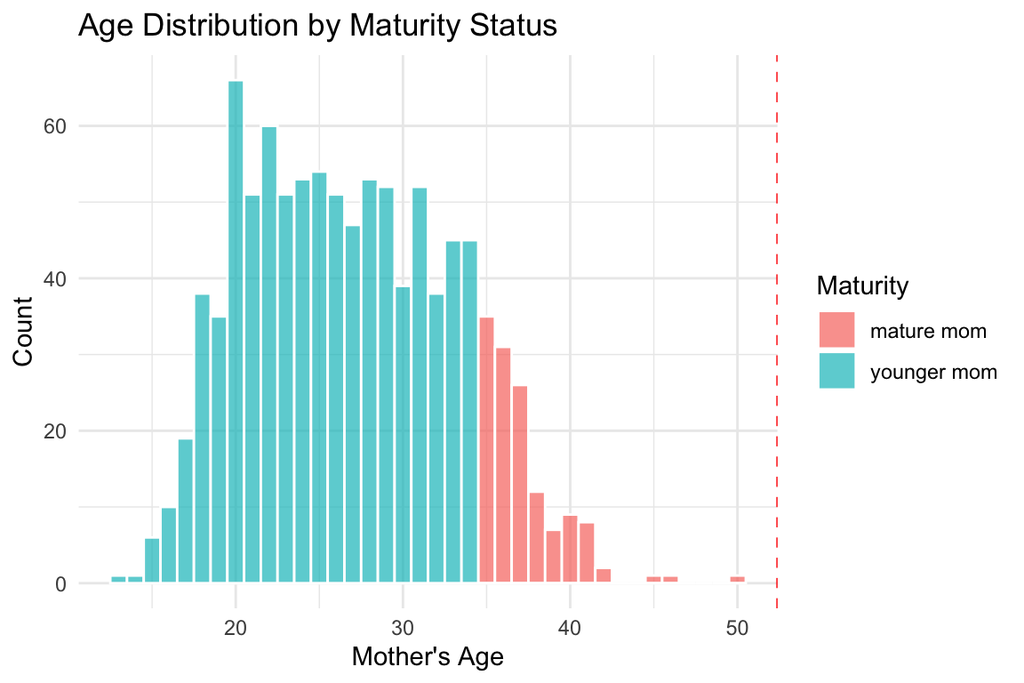

```r
ggplot(nc, aes(x = mage, fill = mature)) +
  geom_histogram(binwidth = 1, color = "white", alpha = 0.7, position = "identity") +
  geom_vline(xintercept = min(nc$mage[is.finite(nc$mage) & nc$mature == "mature"]), color = "red", linetype = "dashed") +
  labs(title = "Age Distribution by Maturity Status",
       x = "Mother's Age", y = "Count", fill = "Maturity") +
  theme_minimal()
```

```r
cutoff <- min(nc$mage[is.finite(nc$mage) & nc$mature == "mature"])
cutoff
```

```
## [1] Inf
```

## 4.5 Exercise 9 - Custom Hypothesis Test (Gender vs. Weeks)

Here we apply our own research question to test whether gestation length differs by baby gender.We chose gender and weeks because fetal development duration may be influenced by sex-specific factors.

```r
newinf(y = nc$weeks, x = nc$gender, est = "mean", type = "ht", null = 0,
       alternative = "twosided", method = "theoretical")
```

```
## Response variable: numerical, Explanatory variable: categorical
## Difference between two means
## Summary statistics:
## n_female = 502, mean_female = 38.2789, sd_female = 3.0232
## n_male = 496, mean_male = 38.3911, sd_male = 2.8377
```

```
## Observed difference between means (female-male) = -0.1122
## H0: mu_female - mu_male = 0
## HA: mu_female - mu_male != 0
## Standard error = 0.186
## Test statistic: Z =  -0.605
## p-value =  0.5454
```

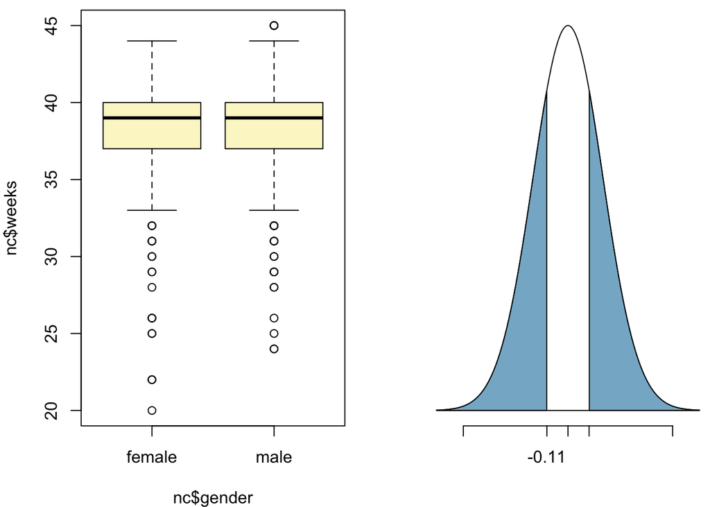

**Interpretation:** This test evaluates whether male and female babies differ in average pregnancy length. A low p-value would indicate a significant difference between genders.

# 5 Conclusion

This lab provided hands-on experience with statistical inference techniques, including hypothesis testing and confidence interval construction. By exploring real birth data, we developed skills in comparing group means, interpreting statistical results, and understanding the connection between visual summaries and formal inference. These are foundational tools for evidence-based decision making in health and social science domains. This lab further solidifies the link between exploratory data analysis and formal inference, making the statistical thinking cycle complete.